# Stat 579 - Homework #8

Urminder Singh

11/13/2018

## Human Development Index

The United Nations Development Programme publishes an annual report on human development across the globe. An interactive tool to visualize some of the data is available at http://hdr.undp.org/en/data

1. Download the RMarkdown file with these homework instructions to use as a template for your work. Make sure to replace “Your Name” in the YAML with your name.
2. Download the data for 2018 from the left side tab stating [Download all 2018 Human Development data](http://hdr.undp.org/sites/default/files/2018_statistical_annex_all.xlsx). This will lead you to an Excel document. Open it and comment on the structure. Focus on table 2: what problems do you see with the file format? List three problems and explain.

The file has a total of 19 sheets. Table 2 contains human development index trends from 1990 till 2017. Problems with the data

- There are missing values in the data
- The data format is not consistent i.e. values under a column are interrupted by names or non numbers and there are blank columns in the dataset.
- The data collected at different intervals. data from 1991 till 1999 is not availalable also data for 2001 till 2009 is not available.
3. There is an R package available online (on CRAN) that allows to read Excel files. Find the package, (install it if necessary), load it and try to read the second table of the file “2018_statistical_annex_all.xlsx” into R (make use of the available parameters). Compare the result in R with what is visible in Excel. Keep track of and comment on all steps in the process. For the write-up assume, that the Excel file is in the same folder as the homework Rmd file. Also assume, that both the TA and I have an updated version of the package installed, i.e. only load the package but do not install it in the code.

We can use readxl package to read xlsx files.

```r
library(tidyverse)
library(readxl)
X2018_statistical_annex_all <- read_excel("2018_statistical_annex_all.xlsx",
    sheet = "Table 2")
#View(X2018_statistical_annex_all)
```

4. Introduce names to the data extracted for Table 2.

```r
names(X2018_statistical_annex_all)<-c("HDI Rank","Country","HDIValue1990","", "HDIValue2000","","HDIValue2010","","HDIValue2012","","HDIValue2014","","HDIValue2015","","HDIValue2016","","HDIValue2017","","ChangeinHDI2012-2017","","AvgAnualHDIgrowth1990-2000","","AvgAnualHDIgrowth2000-2010","","AvgAnualHDIgrowth2010-2017","","AvgAnualHDIgrowth1990-2017")
```

5. Use `tidyr` and `dplyr` functionality to get the data set into the following format (Classification of HDI is very high for [0.8,1], high for [0.7, .8), medium for [.55, .7) and low below .55):

```
  Country     Year    HDI Classification
  <chr>       <chr> <dbl> <fct>
1 Norway      1990  0.850 very high
2 Switzerland 1990  0.832 very high
3 Australia   1990  0.866 very high
4 Ireland     1990  0.763 high
5 Germany     1990  0.801 very high
6 Iceland     1990  0.802 very high
```

```r
#remove first 5 rows
data<-X2018_statistical_annex_all[-(1:5),]
#remove all blank cols
data<-data[,-which(names(data)=="")]
#remove rows which don't contain data
data<-data[-which(is.na(data$HDIValue2017)),]

#rename data
colnames(data)<-sub("HDIValue","",colnames(data))

getClass<- function(m){
  #very high for [0.8,1], high for [0.7, .8), medium for [.55, .7) and low below .55):
  res<-c()

  #print(length(m))
  for(x in m){
  if (x >= 0.8){
   # print("very high")
    res<-c(res,"very high")
  }
  else if (x >= 0.7){
   # print("high")
    res<-c(res,"high")
    }
  else if (x >= 0.55){
   # print("medium")
    res<-c(res,"medium")
    }
  else {
    #print("low")
    res<-c(res,"low")
  }
  }
  return(res)

}

data<-data%>%gather(key = year, value = HDI,3:10) %>% select(Country,year,HDI) %>% mutate(Classification=getClass(HDI))

data$year<-as.character(data$year)
data$HDI<-as.double(data$HDI)
data$Classification<-as.factor(data$Classification)
data$Classification = factor(data$Classification,levels(data$Classification)[c(2,3,1,4)],ordered=TRUE)


head(data)
```

```
## # A tibble: 6 x 4
##   Country     year    HDI Classification
##   <chr>       <chr> <dbl> <ord>
## 1 Norway      1990  0.850 very high
## 2 Switzerland 1990  0.832 very high
## 3 Australia   1990  0.866 very high
## 4 Ireland     1990  0.763 high
## 5 Germany     1990  0.801 very high
## 6 Iceland     1990  0.802 very high
```

6. Use `ggplot` to draw a plot of HDI over time for the US, Norway, Germany, and Canada.

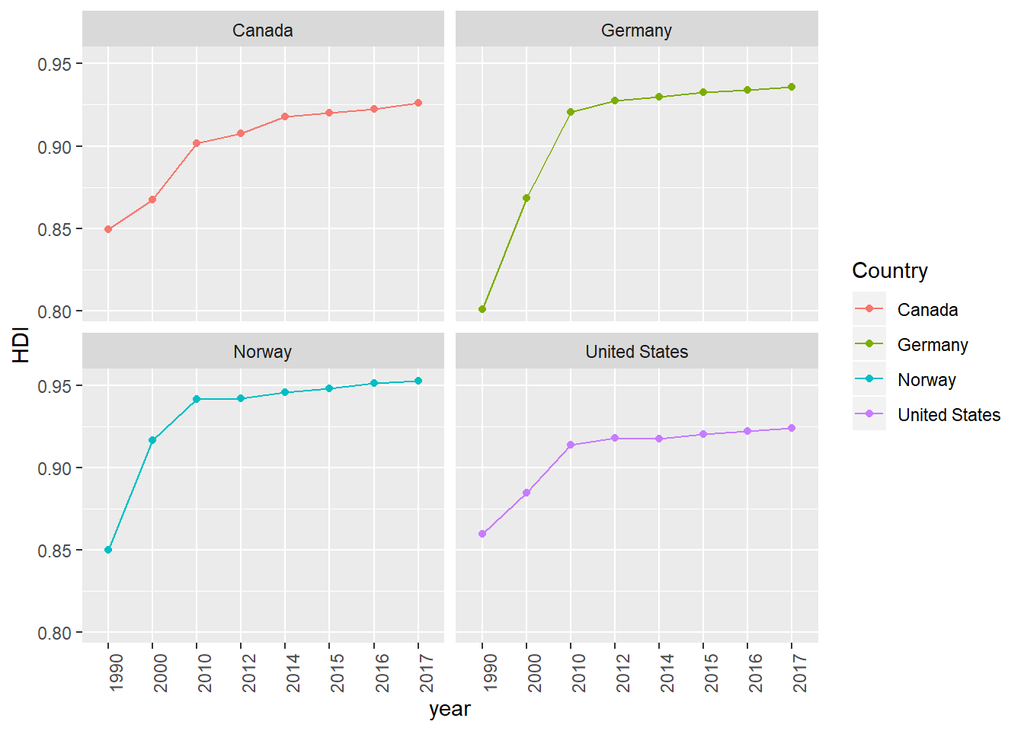

```r
ggplot(data=data%>%filter(Country %in% c("United States","Norway","Germany","Canada")),aes(x=year,y=HDI,color=Country,group = 1))+geom_point()+ geom_line()+facet_wrap(~Country)+theme(axis.text.x = element_text(angle = 90, hjust = 1))
```

7. How many countries switched classifications between 2000 and 2017? How many countries went up, how many countries went down?

```r
data%>%group_by(Country,Classification,year)%>%filter(year==2000 | year==2017)%>% count %>% spread(key = year, value = Classification) %>%
      mutate(change= ifelse(`2000`==`2017`,"no",ifelse(`2000`>=`2017`,"neg","pos")))%>%group_by(change) %>% count()
```

```
## # A tibble: 3 x 2
## # Groups:   change [3]
##   change    nn
##   <chr>  <int>
## 1 neg        1
## 2 no       107
## 3 pos      102
```

Total 103 countries changed classifications between 2000 and 2017. 102 went up where as one went down